# Taller 3

Grupo 1

18/6/2020

# TallerA

## Ejercicio 8:

### Literal c):

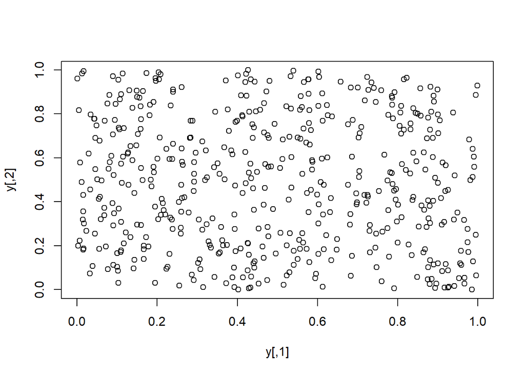

Como podemos ver, al menos en dos dimensiones no se observa problemas de aleatoridad, pero hay que tener en cuenta que si se grafican tripletas de los gráficos, se podrá observar hiperplanos paralelos.

### Literal d):

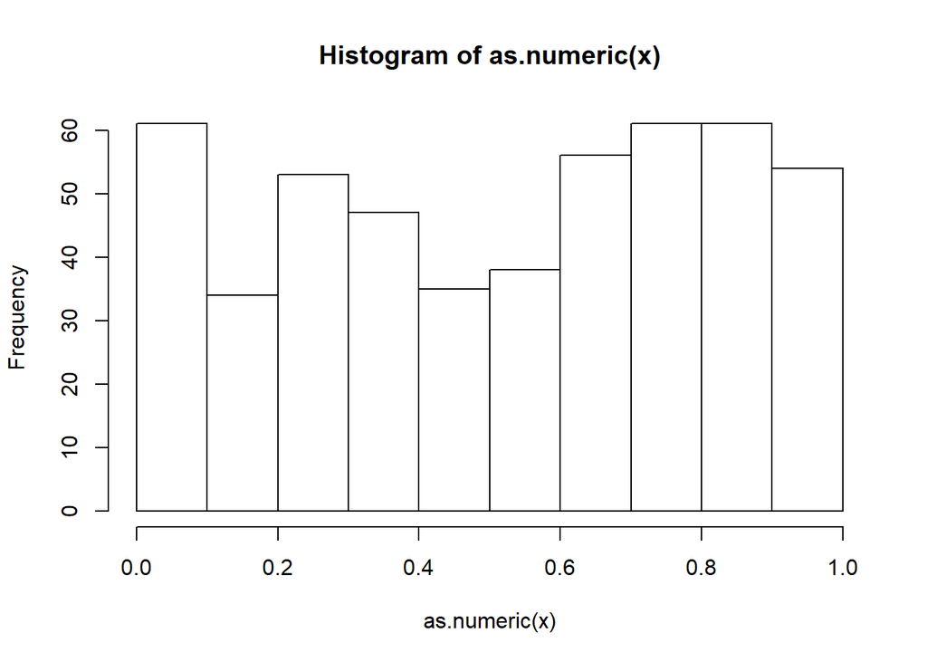

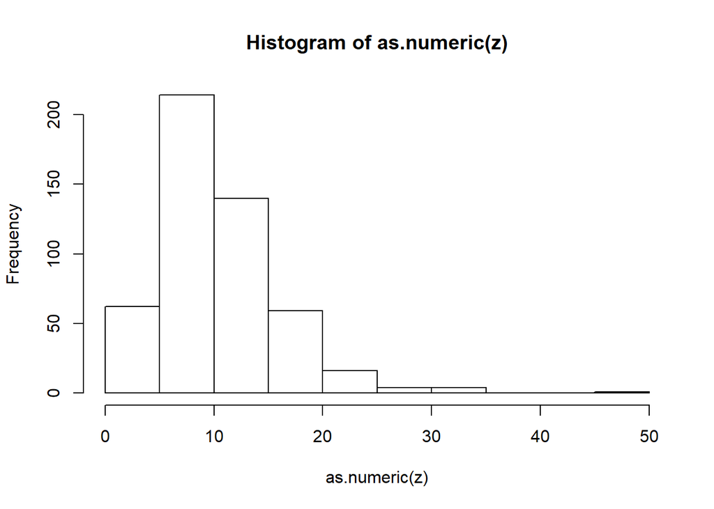

Como se puede ver en el contraste realizado, tanto el p-valor como el estadístico, siguen las distribuciones que se supone que deberían seguir, por lo que sería correcto considerar independencia entre generaciones para cada 10 datos.

```
## Proporcion de rechazos al 1% = 0.032
```

```
## Proporcion de rechazos al 5% = 0.068
```

```
## Proporcion de rechazos al 10% = 0.122
```

# Taller

## Ejercicio 2:

CONTRASTE DE HIPOTESIS CUANDO NO SE CUMPLE LA HIPOTESIS NULA EN UNA DISTRIBUCION NORMAL CON VARIANZA 36 H0: Mu=20 Ha: Mu>20

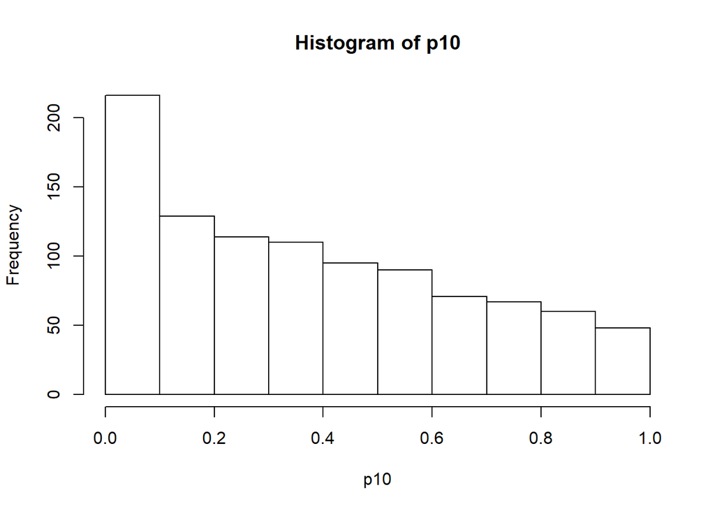

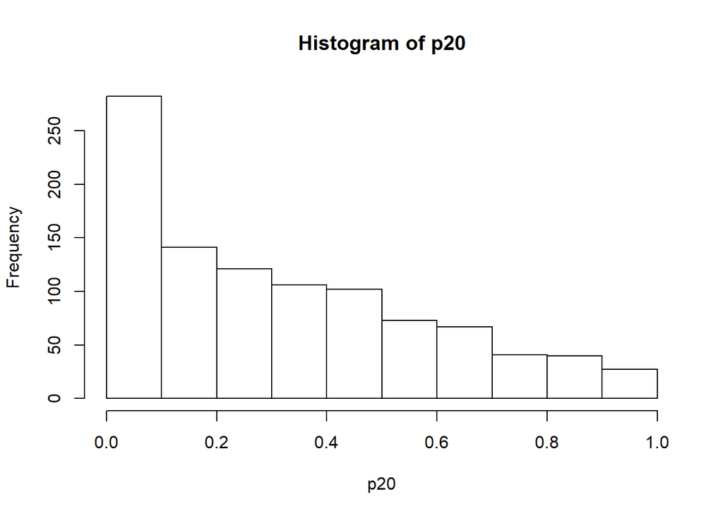

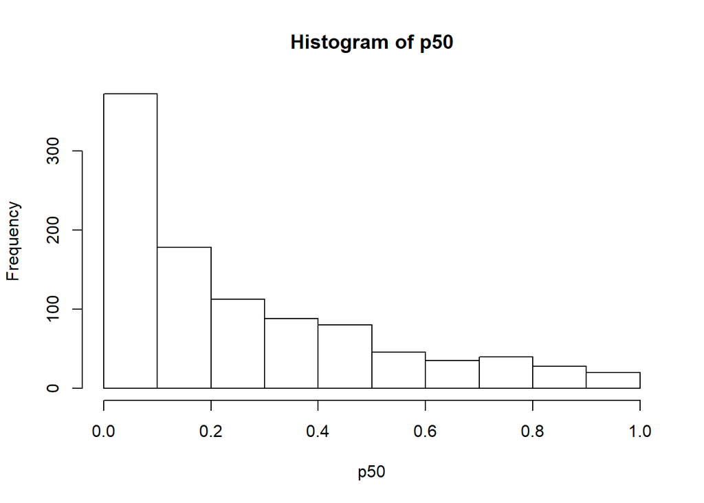

COMO SE PUEDE VER SON HISTOGRAMAS SESGADOS HACIA LA IZQUIERDA, POR LO TANTO HAY QUE RECHAZAR LA HIPOTESIS.

CALCULO DE LA POTENCIA DE LA PRUEBA

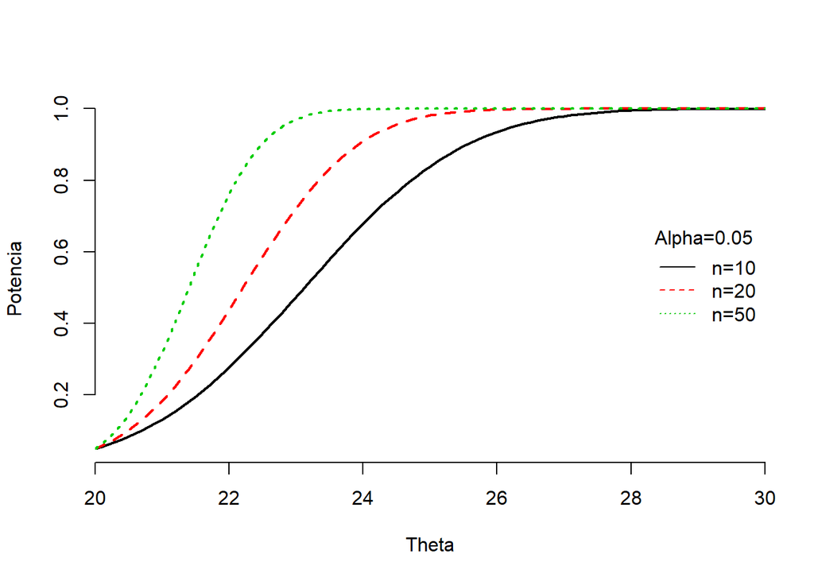

AQUÍ SE CONCLUYE QUE A MEDIDA QUE AUMENTA EL TAMAÑO DE MUESTRA, AUMENTA LA PROBABILIDAD DE RECHAZAR UNA HIPÓTESIS FALSA.